# IS 6489: Module 7 | Airbnb

Meag Tessmann

Nov 4-10

## Load data and packages

```r
library(tidyverse)
library(caret)
a <- read_csv("airbnb.csv")
glimpse(a)
```

```
## Observations: 2,000
## Variables: 29
## $ id                          <dbl> 12657038, 13083682, 10638522, 971116…
## $ name                        <chr> "Luxury home by Golden Gate Park", "…
## $ summary                     <chr> "Beautiful, re-modeled, spacious fam…
## $ host_response_time          <chr> "within a few hours", "within an hou…
## $ host_response_rate          <dbl> 90, 100, 100, 100, 100, 100, 100, NA…
## $ host_is_superhost           <lgl> FALSE, TRUE, TRUE, TRUE, TRUE, TRUE,…
## $ neighbourhood_cleansed      <chr> "Inner Sunset", "Mission", "Mission"…
## $ property_type               <chr> "House", "Townhouse", "Apartment", "…
## $ room_type                   <chr> "Entire home/apt", "Private room", "…
## $ accommodates                <dbl> 8, 2, 5, 2, 4, 5, 2, 4, 2, 4, 4, 6, …
## $ bathrooms                   <dbl> 3.0, 1.0, 1.5, 1.0, 1.0, 1.0, 1.0, 1…
## $ bedrooms                    <dbl> 3, 1, 1, 1, 0, 2, 0, 2, 0, 2, 1, 3, …
## $ beds                        <dbl> 4, 1, 1, 1, 2, 2, 1, 3, 1, 2, 2, 2, …
```

[output cut: 16 more lines]

```r
summary(a)
```

```
##        id               name             summary
##  Min.   :     958   Length:2000        Length:2000
##  1st Qu.: 6161390   Class :character   Class :character
##  Median :16394138   Mode  :character   Mode  :character
##  Mean   :16205499
##  3rd Qu.:24656210
##  Max.   :37156053
##
##  host_response_time host_response_rate host_is_superhost
##  Length:2000        Min.   :  0.0      Mode :logical
##  Class :character   1st Qu.:100.0      FALSE:1002
##  Mode  :character   Median :100.0      TRUE :998
##                     Mean   : 96.9
##                     3rd Qu.:100.0
##                     Max.   :100.0
##                     NA's   :194
##  neighbourhood_cleansed property_type       room_type
##  Length:2000            Length:2000        Length:2000
##  Class :character       Class :character   Class :character
##  Mode  :character       Mode  :character   Mode  :character
##
##
##
##
##   accommodates     bathrooms         bedrooms          beds
##  Min.   : 1.00   Min.   : 0.000   Min.   :0.000   Min.   :0.000
##  1st Qu.: 2.00   1st Qu.: 1.000   1st Qu.:1.000   1st Qu.:1.000
##  Median : 2.00   Median : 1.000   Median :1.000   Median :1.000
##  Mean   : 3.29   Mean   : 1.364   Mean   :1.401   Mean   :1.792
##  3rd Qu.: 4.00   3rd Qu.: 1.500   3rd Qu.:2.000   3rd Qu.:2.000
##  Max.   :16.00   Max.   :10.000   Max.   :7.000   Max.   :9.000
##                  NA's   :6                        NA's   :1
##    bed_type             price       security_deposit  cleaning_fee
##  Length:2000        Min.   : 10.0   Min.   :  0.0    Min.   :  0.0
##  Class :character   1st Qu.: 99.0   1st Qu.:  0.0    1st Qu.: 49.0
##  Mode  :character   Median :150.0   Median :  0.0    Median : 89.0
##                     Mean   :199.1   Mean   :160.4    Mean   :103.6
##                     3rd Qu.:249.0   3rd Qu.:300.0    3rd Qu.:148.0
##                     Max.   :999.0   Max.   :999.0    Max.   :663.0
##                     NA's   :21                       NA's   :151
```

[output cut: 17 more lines]

```
##  Min.   : 2.000              Min.   : 2.000         Min.   : 2.00
##  1st Qu.:10.000              1st Qu.:10.000         1st Qu.: 9.00
##  Median :10.000              Median :10.000         Median :10.00
##  Mean   : 9.835              Mean   : 9.701         Mean   : 9.41
##  3rd Qu.:10.000              3rd Qu.:10.000         3rd Qu.:10.00
##  Max.   :10.000              Max.   :10.000         Max.   :10.00
##  NA's   :15                  NA's   :16             NA's   :16
##  instant_bookable cancellation_policy annual_bookings
##  Mode :logical    Length:2000         Min.   :  1.00
##  FALSE:1245       Class :character    1st Qu.:  9.00
##  TRUE :755        Mode  :character    Median : 32.00
##                                       Mean   : 54.36
##                                       3rd Qu.: 82.00
##                                       Max.   :355.00
##
```

## Data Preparation

```r
# Grain
length(unique(a$id))==nrow(a) # yes
```

```
## [1] TRUE
```

```r
# Prepare data
a <- a %>%
  dplyr::select(-id, -name, -summary) %>%
  mutate(host_response_time = factor(host_response_time),
         neighbourhood_cleansed = factor(neighbourhood_cleansed),
         property_type = factor(property_type),
         room_type = factor(room_type),
         bed_type = factor(bed_type),
         cancellation_policy = factor(cancellation_policy),
         cleaning_fee = replace_na(cleaning_fee, 0))

# Summarize new dataset
summary(a)
```

```
##           host_response_time host_response_rate host_is_superhost
##  a few days or more:  14     Min.   :  0.0      Mode :logical
##  N/A               : 194     1st Qu.:100.0      FALSE:1002
##  within a day      : 177     Median :100.0      TRUE :998
##  within a few hours: 367     Mean   : 96.9
##  within an hour    :1248     3rd Qu.:100.0
##                              Max.   :100.0
##                              NA's   :194
##            neighbourhood_cleansed        property_type
##  Mission              : 205       Apartment     :747
##  Western Addition     : 162       House         :591
##  Downtown/Civic Center: 144       Condominium   :206
##  South of Market      : 119       Guest suite   :170
##  Castro/Upper Market  : 116       Boutique hotel: 72
##  Bernal Heights       : 105       Townhouse     : 39
##  (Other)              :1149       (Other)       :175
##            room_type     accommodates     bathrooms         bedrooms
##  Entire home/apt:1163   Min.   : 1.00   Min.   : 0.000   Min.   :0.000
##  Private room   : 784   1st Qu.: 2.00   1st Qu.: 1.000   1st Qu.:1.000
##  Shared room    :  53   Median : 2.00   Median : 1.000   Median :1.000
##                         Mean   : 3.29   Mean   : 1.364   Mean   :1.401
##                         3rd Qu.: 4.00   3rd Qu.: 1.500   3rd Qu.:2.000
##                         Max.   :16.00   Max.   :10.000   Max.   :7.000
##                                         NA's   :6
##       beds                bed_type        price       security_deposit
##  Min.   :0.000   Airbed       :   3   Min.   : 10.0   Min.   :  0.0
##  1st Qu.:1.000   Couch        :   4   1st Qu.: 99.0   1st Qu.:  0.0
##  Median :1.000   Futon        :  12   Median :150.0   Median :  0.0
##  Mean   :1.792   Pull-out Sofa:   6   Mean   :199.1   Mean   :160.4
##  3rd Qu.:2.000   Real Bed     :1975   3rd Qu.:249.0   3rd Qu.:300.0
##  Max.   :9.000                        Max.   :999.0   Max.   :999.0
##  NA's   :1                            NA's   :21
##   cleaning_fee    guests_included   extra_people    review_scores_rating
##  Min.   :  0.00   Min.   : 1.000   Min.   :  0.00   Min.   : 20.00
##  1st Qu.: 35.00   1st Qu.: 1.000   1st Qu.:  0.00   1st Qu.: 95.00
##  Median : 80.00   Median : 1.000   Median :  0.00   Median : 98.00
##  Mean   : 95.73   Mean   : 1.833   Mean   : 18.02   Mean   : 95.69
##  3rd Qu.:125.00   3rd Qu.: 2.000   3rd Qu.: 25.00   3rd Qu.:100.00
##  Max.   :663.00   Max.   :16.000   Max.   :300.00   Max.   :100.00
##                                                     NA's   :14
```

[output cut: 9 more lines]

```
##  Min.   : 2.000              Min.   : 2.000         Min.   : 2.00
##  1st Qu.:10.000              1st Qu.:10.000         1st Qu.: 9.00
##  Median :10.000              Median :10.000         Median :10.00
##  Mean   : 9.835              Mean   : 9.701         Mean   : 9.41
##  3rd Qu.:10.000              3rd Qu.:10.000         3rd Qu.:10.00
##  Max.   :10.000              Max.   :10.000         Max.   :10.00
##  NA's   :15                  NA's   :16             NA's   :16
##  instant_bookable                  cancellation_policy annual_bookings
##  Mode :logical    flexible                   :319      Min.   :  1.00
##  FALSE:1245       moderate                   :755      1st Qu.:  9.00
##  TRUE :755        strict                     :  4      Median : 32.00
##                   strict_14_with_grace_period:915      Mean   : 54.36
##                   super_strict_30            :  5      3rd Qu.: 82.00
##                   super_strict_60            :  1      Max.   :355.00
##                   NA's                       :  1
```

```r
# Look more closely at neighbourhood_cleansed
a %>%
  count(neighbourhood_cleansed) %>%
  mutate(cum_count = seq(1, length(neighbourhood_cleansed)))
```

```
## # A tibble: 35 x 3
##    neighbourhood_cleansed     n cum_count
##    <fct>                  <int>     <int>
##  1 Bayview                   36         1
##  2 Bernal Heights           105         2
##  3 Castro/Upper Market      116         3
##  4 Chinatown                 31         4
##  5 Crocker Amazon             8         5
##  6 Diamond Heights            3         6
##  7 Downtown/Civic Center    144         7
##  8 Excelsior                 49         8
##  9 Financial District        30         9
## 10 Glen Park                 17        10
## # … with 25 more rows
```

```r
# 35 neighborhoods

# Look more closely at property_type
a %>%
  count(property_type)
```

```
## # A tibble: 22 x 2
##    property_type         n
##    <fct>             <int>
##  1 Aparthotel            8
##  2 Apartment           747
##  3 Bed and breakfast    13
##  4 Boat                  1
##  5 Boutique hotel       72
##  6 Bungalow              6
##  7 Condominium         206
##  8 Cottage               1
##  9 Earth house           1
## 10 Guest suite         170
## # … with 12 more rows
```

```r
# Look more closely at room_type
a %>%
  count(room_type)
```

```
## # A tibble: 3 x 2
##   room_type           n
##   <fct>           <int>
## 1 Entire home/apt  1163
## 2 Private room      784
## 3 Shared room        53
```

```r
# Look more closely at bed_type
a %>%
  count(bed_type)
```

```
## # A tibble: 5 x 2
##   bed_type          n
##   <fct>         <int>
## 1 Airbed            3
## 2 Couch             4
## 3 Futon            12
## 4 Pull-out Sofa     6
## 5 Real Bed       1975
```

```r
# Look more closely at cancellation policy
a %>%
  count(cancellation_policy)
```

```
## # A tibble: 7 x 2
##   cancellation_policy             n
##   <fct>                       <int>
## 1 flexible                      319
## 2 moderate                      755
## 3 strict                          4
## 4 strict_14_with_grace_period   915
## 5 super_strict_30                 5
## 6 super_strict_60                 1
## 7 <NA>                            1
```

```r
a <- a %>%
  mutate(host_response_time = na_if(host_response_time, "N/A"),
         host_response_time = factor(host_response_time))
```

```r
na.omit(a) %>%
  nrow # or
```

```
## [1] 1767
```

```r
complete.cases(a) %>%
  sum
```

```
## [1] 1767
```

**Create a numeric predictor matrix**.

```r
preds <- dummyVars(annual_bookings ~., data = a, fullRank = T) %>%
  predict(newdata = a)

dim(preds)
```

```
## [1] 2000   88
```

**Remove near zero variance predictors from the numeric predictor matrix**.

```r
preds <- preds[, -nzv(preds)]

dim(preds)
```

```
## [1] 2000   34
```

**For convenience, add the outcome variable to the dummy variable matrix**.

```r
preds <- data.frame(preds)

preds$annual_bookings <- a$annual_bookings

dim(preds)
```

```
## [1] 2000   35
```

## Q1

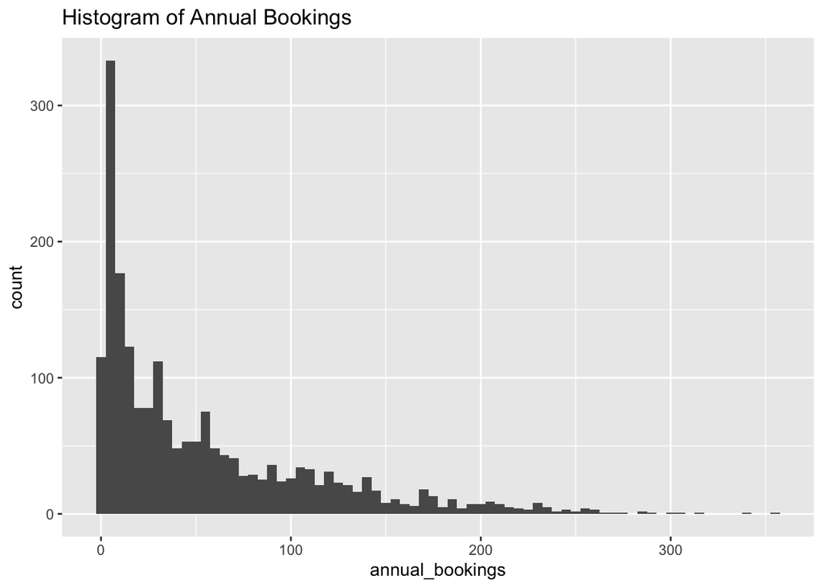

```r
a %>%
  ggplot(aes(annual_bookings)) +
  geom_histogram(binwidth = 5) +
  ggtitle("Histogram of Annual Bookings")
```

```r
a %>%
  summarize(
    n = NROW(annual_bookings),
    q1 = quantile(annual_bookings, .25),
    median = median(annual_bookings),
    q3 = quantile(annual_bookings, .75),
    sd = sd(annual_bookings),
    mean = mean(annual_bookings)
  )
```

```
## # A tibble: 1 x 6
##       n    q1 median    q3    sd  mean
##   <int> <dbl>  <dbl> <dbl> <dbl> <dbl>
## 1  2000     9     32    82  59.0  54.4
```

> *Answer*  
> Annual bookings is right skewed and does not appear normal. The mean is almost half of a standard deviation higher than the median. The histogram shape is suggestive that taking the log of annual bookings might be useful.

## Q2

```r
set.seed(123)

model_q2 <- train(y = preds$annual_bookings,x = select(preds, -annual_bookings),  preProcess=c("medianImpute", "center", "scale"), method="lm")

est_q2 <- preds %>%
  dplyr::select(annual_bookings) %>%
  mutate(
    est_annual_bookings = predict(model_q2, newdata = preds),
    priceDiff = annual_bookings - est_annual_bookings,
  )

summary_q2 <- est_q2 %>%
  summarize(
    MAE = MAE(annual_bookings, est_annual_bookings),
    RMSE = RMSE(annual_bookings, est_annual_bookings),
    R2 = R2(annual_bookings, est_annual_bookings),
  )

summary_q2
```

```
##        MAE     RMSE        R2
## 1 36.62222 49.02834 0.3083615
```

```r
summary(model_q2)
```

```
##
## Call:
## lm(formula = .outcome ~ ., data = dat)
##
## Residuals:
##      Min       1Q   Median       3Q      Max
## -123.684  -32.677   -9.536   22.471  261.510
##
## Coefficients:
##                                                  Estimate Std. Error
## (Intercept)                                      53.75743    1.10894
## host_response_time.within.a.day                  -1.98747    4.12764
## host_response_time.within.a.few.hours            -0.27068    5.49910
## host_response_time.within.an.hour                 7.72718    6.25032
## host_is_superhostTRUE                             8.77733    1.21537
## neighbourhood_cleansed.Bernal.Heights            -2.94034    1.13730
## neighbourhood_cleansed.Castro.Upper.Market        1.42508    1.15381
## neighbourhood_cleansed.Downtown.Civic.Center     -3.48269    1.28413
## neighbourhood_cleansed.Mission                    0.57023    1.16706
## neighbourhood_cleansed.South.of.Market            0.85926    1.17869
## neighbourhood_cleansed.Western.Addition          -0.01109    1.16548
## property_type.Apartment                           5.39866    1.83557
## property_type.Condominium                         1.88425    1.47909
## property_type.Guest.suite                        17.63318    1.48684
## property_type.House                               8.59998    1.84526
## room_type.Private.room                            6.98217    1.43947
## accommodates                                      6.78626    2.46495
## bathrooms                                        -1.86917    1.24363
## bedrooms                                         -4.41581    2.17719
## beds                                              3.17466    2.24611
## price                                            -4.85604    1.49592
## security_deposit                                 -2.94145    1.18081
## cleaning_fee                                    -11.59362    1.44834
## guests_included                                   2.76972    1.52399
## extra_people                                      1.66069    1.21729
## review_scores_rating                             -4.83548    2.01829
## review_scores_accuracy                            1.81707    1.69288
## review_scores_cleanliness                         2.81341    1.54970
## review_scores_checkin                             2.93467    1.45512
## review_scores_communication                       1.61295    1.61277
```

[output cut: 32 more lines]

```
## review_scores_accuracy                            1.073  0.28324
## review_scores_cleanliness                         1.815  0.06961 .
## review_scores_checkin                             2.017  0.04385 *
## review_scores_communication                       1.000  0.31738
## review_scores_location                            2.535  0.01132 *
## review_scores_value                              -1.485  0.13771
## instant_bookableTRUE                              3.928 8.87e-05 ***
## cancellation_policy.moderate                      2.479  0.01327 *
## cancellation_policy.strict_14_with_grace_period  -1.767  0.07746 .
## ---
## Signif. codes:  0 '***' 0.001 '**' 0.01 '*' 0.05 '.' 0.1 ' ' 1
##
## Residual standard error: 49.46 on 1965 degrees of freedom
## Multiple R-squared:  0.3084, Adjusted R-squared:  0.2964
## F-statistic: 25.77 on 34 and 1965 DF,  p-value: < 2.2e-16
```

```r
(model_q2$results)
```

```
##   intercept     RMSE  Rsquared      MAE  RMSESD RsquaredSD    MAESD
## 1      TRUE 50.01246 0.2793378 37.57537 1.27469 0.02267005 0.868573
```

```r
error_high <- median(preds$annual_bookings) + summary_q2$RMSE
error_low <- median(preds$annual_bookings) - summary_q2$RMSE
(preds$annual_bookings < error_low) %>%
  mean()
```

```
## [1] 0
```

```r
(preds$annual_bookings < error_high) %>%
  mean()
```

```
## [1] 0.7485
```

> *Answer*  
> Estimated RSME: 50.01246  
> In-sample RSME: 49.02834  
> I would say this model is not too performant. If we were predicting a median observation, the error range would be 0 to 81—a range which ~75% of the observations fall into.

## Q3

```r
set.seed(123)

model_q3 <- train(
  y = preds$annual_bookings,
  x = select(preds, -annual_bookings),
  preProcess=c("medianImpute", "center", "scale"),
  method="glmnet",
  tuneGrid = expand.grid(
    alpha = seq(0,.15,.05), #started with 0-1, and narrowed down to this range after experimentation
    lambda = seq(1,15,.05)  # started with the linear RSME, 0 to 50, and narrowed with experimentation
    )
  )

est_q3 <- preds %>%
  dplyr::select(annual_bookings) %>%
  mutate(
    est_annual_bookings = predict(model_q3, newdata = preds),
    priceDiff = annual_bookings - est_annual_bookings,
  )

summary_q3 <- est_q3 %>%
  summarize(
    MAE = MAE(annual_bookings, est_annual_bookings),
    RMSE = RMSE(annual_bookings, est_annual_bookings),
    R2 = R2(annual_bookings, est_annual_bookings),
  )

summary_q3
```

```
##        MAE     RMSE        R2
## 1 36.54985 49.10431 0.3069973
```

```r
summary(model_q3)
```

```
##             Length Class      Mode
## a0           100   -none-     numeric
## beta        3400   dgCMatrix  S4
## df           100   -none-     numeric
## dim            2   -none-     numeric
## lambda       100   -none-     numeric
## dev.ratio    100   -none-     numeric
## nulldev        1   -none-     numeric
## npasses        1   -none-     numeric
## jerr           1   -none-     numeric
## offset         1   -none-     logical
## call           5   -none-     call
## nobs           1   -none-     numeric
## lambdaOpt      1   -none-     numeric
## xNames        34   -none-     character
## problemType    1   -none-     character
## tuneValue      2   data.frame list
## obsLevels      1   -none-     logical
## param          0   -none-     list
```

```r
(model_q3$results)
```

```
##      alpha lambda     RMSE  Rsquared      MAE   RMSESD RsquaredSD
## 1     0.00   1.00 49.95212 0.2799254 37.45006 1.267755 0.02268760
## 2     0.00   1.05 49.95212 0.2799254 37.45006 1.267755 0.02268760
## 3     0.00   1.10 49.95212 0.2799254 37.45006 1.267755 0.02268760
## 4     0.00   1.15 49.95212 0.2799254 37.45006 1.267755 0.02268760
## 5     0.00   1.20 49.95212 0.2799254 37.45006 1.267755 0.02268760
## 6     0.00   1.25 49.95212 0.2799254 37.45006 1.267755 0.02268760
## 7     0.00   1.30 49.95212 0.2799254 37.45006 1.267755 0.02268760
## 8     0.00   1.35 49.95212 0.2799254 37.45006 1.267755 0.02268760
## 9     0.00   1.40 49.95212 0.2799254 37.45006 1.267755 0.02268760
## 10    0.00   1.45 49.95212 0.2799254 37.45006 1.267755 0.02268760
## 11    0.00   1.50 49.95212 0.2799254 37.45006 1.267755 0.02268760
## 12    0.00   1.55 49.95212 0.2799254 37.45006 1.267755 0.02268760
## 13    0.00   1.60 49.95212 0.2799254 37.45006 1.267755 0.02268760
## 14    0.00   1.65 49.95212 0.2799252 37.45002 1.267755 0.02268746
```

[output cut: 2235 more lines]

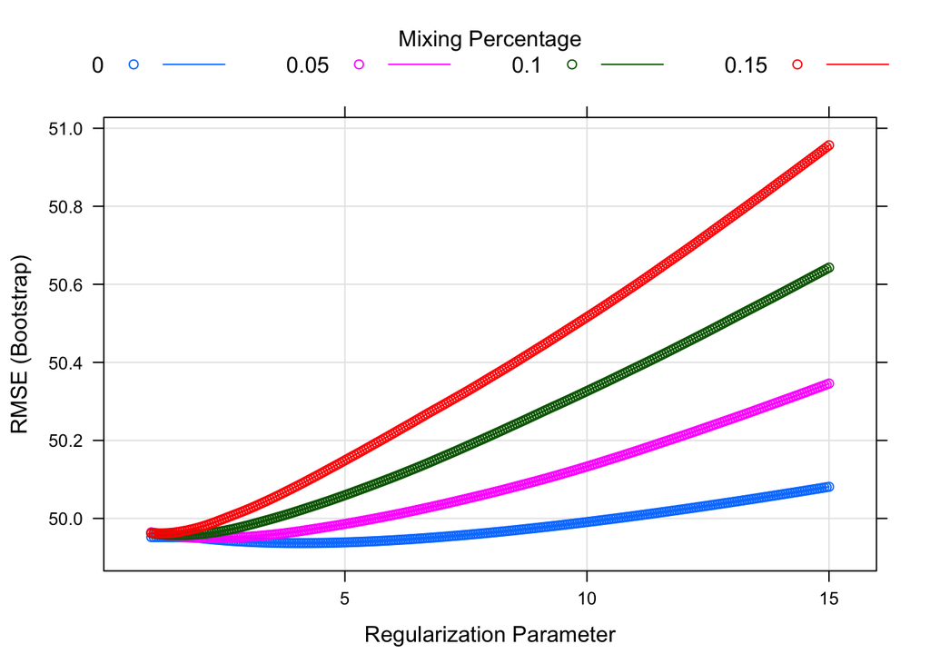

```r
plot(model_q3)
```

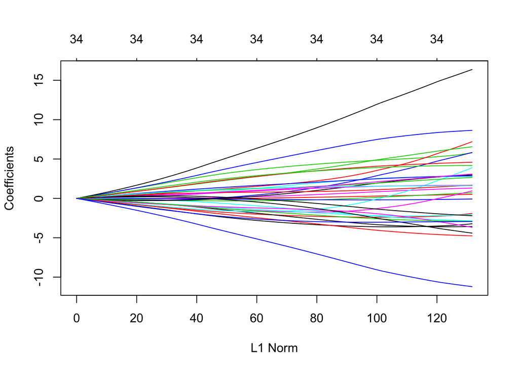

```r
plot(model_q3$finalModel)
```

```r
model_q3$finalModel$tuneValue
```

```
##    alpha lambda
## 63     0    4.1
```

```r
coef(model_q3$finalModel, model_q3$finalModel$tuneValue$lambda)
```

```
## 35 x 1 sparse Matrix of class "dgCMatrix"
##                                                           1
## (Intercept)                                      53.7679752
## host_response_time.within.a.day                  -3.4764438
## host_response_time.within.a.few.hours            -2.2227778
## host_response_time.within.an.hour                 5.3551589
## host_is_superhostTRUE                             8.4213749
## neighbourhood_cleansed.Bernal.Heights            -2.7354049
## neighbourhood_cleansed.Castro.Upper.Market        1.1989892
## neighbourhood_cleansed.Downtown.Civic.Center     -3.6002069
## neighbourhood_cleansed.Mission                    0.4492539
## neighbourhood_cleansed.South.of.Market            0.5465242
## neighbourhood_cleansed.Western.Addition          -0.1255250
## property_type.Apartment                           2.5311875
## property_type.Condominium                         0.1269258
## property_type.Guest.suite                        15.0997502
## property_type.House                               5.9417861
## room_type.Private.room                            6.1028752
## accommodates                                      4.9233443
## bathrooms                                        -2.1742756
## bedrooms                                         -3.0507377
## beds                                              2.7694804
## price                                            -4.6261890
## security_deposit                                 -2.8634381
## cleaning_fee                                    -10.7191448
## guests_included                                   2.7685060
## extra_people                                      1.6498832
## review_scores_rating                             -3.9026767
## review_scores_accuracy                            1.4882517
## review_scores_cleanliness                         2.4706255
## review_scores_checkin                             2.8017817
## review_scores_communication                       1.6023493
## review_scores_location                            2.8177685
## review_scores_value                              -2.0023704
## instant_bookableTRUE                              4.4738225
## cancellation_policy.moderate                      4.1510599
## cancellation_policy.strict_14_with_grace_period  -2.9570665
```

> *Answer*  
> The linear and glmnet models are very similar in performance. As seen below, their in-sample and estimated RSME and R2 values are pretty much the same. In fact, we can see that the glmnet found a Ridge model (alpha==0) to be most performant and indeed from the graph in the next question, we can see the coefficients were hardly altered at all compared to the linear model, implying an almost linear model resulting from the glmnet training was most performant. It might be useful to use the glmnet model for coefficient comparison and a uncentered and unscaled linear model for interpretation.  
> Linear Model  
> In-sample RSME: 49.02834  
> In-sample R2: 0.3083615  
> Estimated RSME: 50.01246  
> Estimated R2: 0.2793378  
> Regularization model  
> In-sample RSME: 49.10431  
> In-sample R2: 0.3069973  
> Estimated RSME: 49.93684  
> Estimated R2: 0.2797758

## Q4

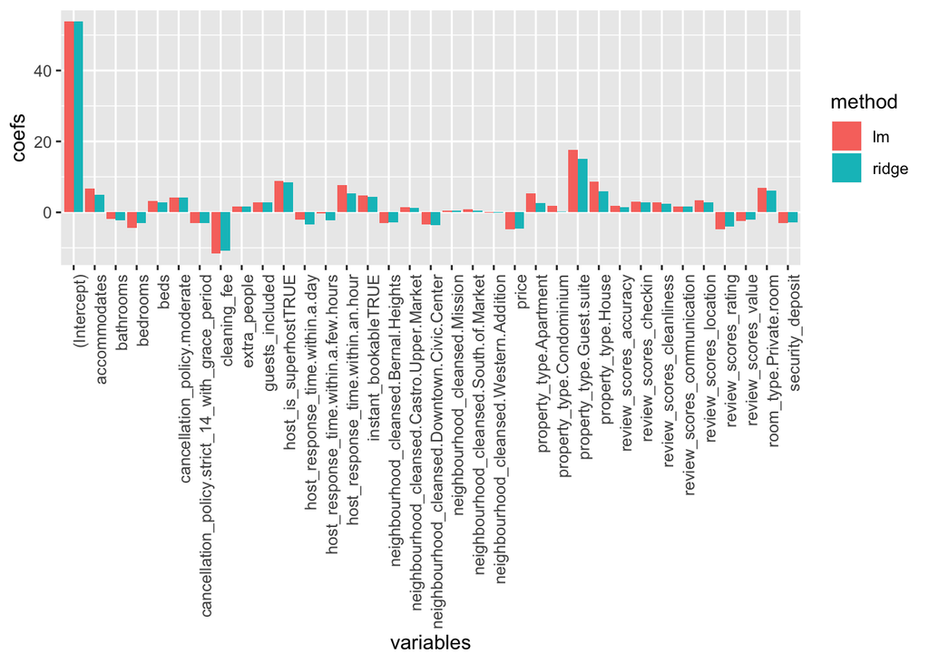

```r
compare <- data.frame(variables = rep(as.character(names(coef(model_q2$finalModel))),2))
compare$method <- c(rep("ridge", 35), rep("lm", 35))
compare$coefs <- c(as.numeric(as.character(coef(model_q3$finalModel, model_q3$bestTune$lambda))),
                   as.numeric(as.character(coef(model_q2$finalModel))))

ggplot(compare, aes(variables, coefs, group=method, fill=method)) +
  geom_bar(stat = "identity",position="dodge") +
  theme(axis.text.x = element_text(angle = 90, hjust = 1))
```

## Q5

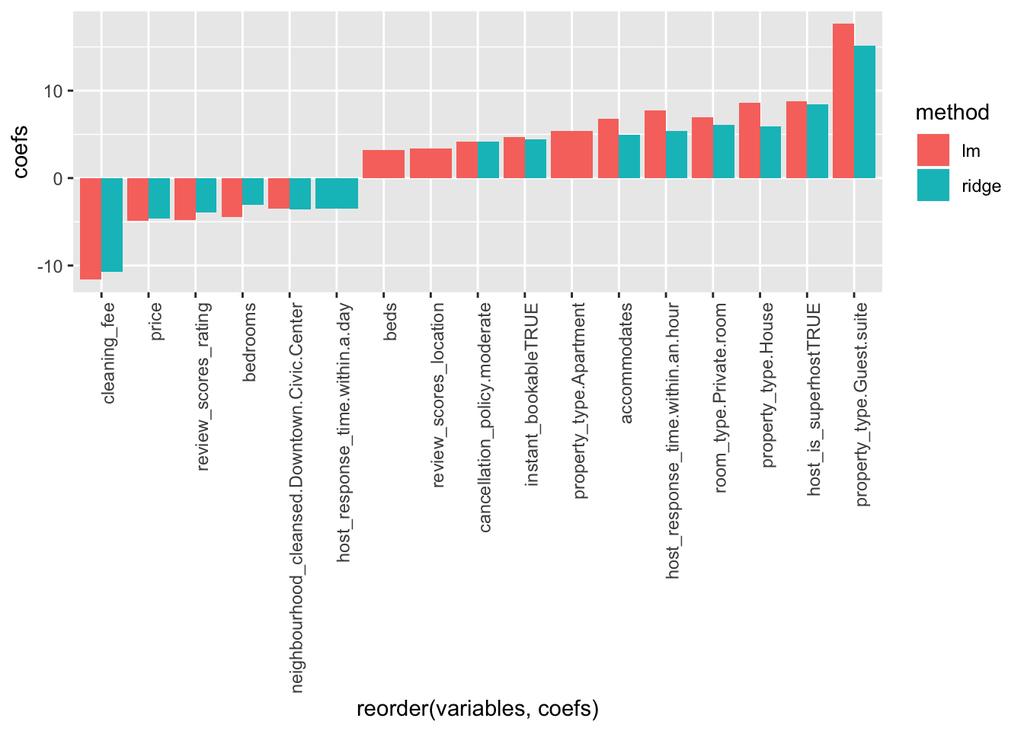

```r
# make a ordered graph, filtered to the highest coefficients
compare <- data.frame(variables = rep(as.character(names(coef(model_q2$finalModel))),2))
compare$method <- c(rep("ridge", 35), rep("lm", 35))
compare$coefs <- c(as.numeric(as.character(coef(model_q3$finalModel, model_q3$bestTune$lambda))),
                   as.numeric(as.character(coef(model_q2$finalModel))))

compare <- compare %>% filter(variables!="(Intercept)") %>% filter( abs(coefs)>3)

ggplot(compare, aes(reorder(variables, coefs), coefs, group=method, fill=method)) +
  geom_bar(stat = "identity",position="dodge") +
  theme(axis.text.x = element_text(angle = 90, hjust = 1))
```

```r
compare
```

```
##                                       variables method      coefs
## 1               host_response_time.within.a.day  ridge  -3.476444
## 2             host_response_time.within.an.hour  ridge   5.355159
## 3                         host_is_superhostTRUE  ridge   8.421375
## 4  neighbourhood_cleansed.Downtown.Civic.Center  ridge  -3.600207
## 5                     property_type.Guest.suite  ridge  15.099750
## 6                           property_type.House  ridge   5.941786
## 7                        room_type.Private.room  ridge   6.102875
## 8                                  accommodates  ridge   4.923344
## 9                                      bedrooms  ridge  -3.050738
## 10                                        price  ridge  -4.626189
## 11                                 cleaning_fee  ridge -10.719145
## 12                         review_scores_rating  ridge  -3.902677
## 13                         instant_bookableTRUE  ridge   4.473822
## 14                 cancellation_policy.moderate  ridge   4.151060
```

[output cut: 16 more lines]

```r
# checking avg bookings for different response times
a %>%
  filter(host_response_time=="within an hour") %>%
  summarize(
    mean = mean(annual_bookings)
  ) #70.27644
```

```
## # A tibble: 1 x 1
##    mean
##   <dbl>
## 1  70.3
```

```r
a %>%
  filter(host_response_time=="within a day") %>%
  summarize(
    mean = mean(annual_bookings)
  ) #21.28814
```

```
## # A tibble: 1 x 1
##    mean
##   <dbl>
## 1  21.3
```

```r
# checking avg bookings for superhost
a %>%
  filter(host_is_superhost==TRUE) %>%
  summarize(
    mean = mean(annual_bookings)
  )     # 69.07916
```

```
## # A tibble: 1 x 1
##    mean
##   <dbl>
## 1  69.1
```

```r
a %>%
  filter(host_is_superhost==FALSE) %>%
  summarize(
    mean = mean(annual_bookings)
  ) #39.70359
```

```
## # A tibble: 1 x 1
##    mean
##   <dbl>
## 1  39.7
```

```r
# what percent of bookings are under the median + error rate
(a$annual_bookings < (53.7679752+50)) %>% mean()
```

```
## [1] 0.812
```

```r
(a$annual_bookings < (53.7679752-50)) %>% mean()
```

```
## [1] 0.099
```

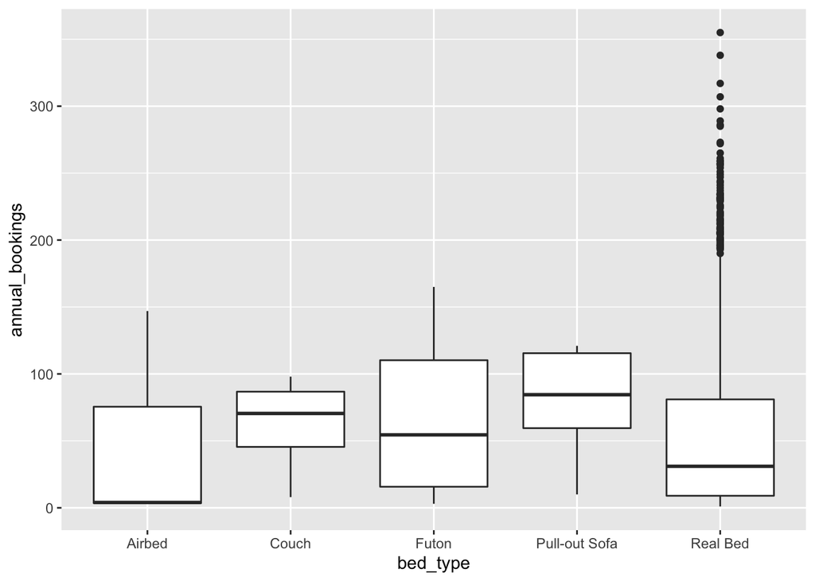

```r
# See if there's specific bed types to recommend, using as a proxy for additional beds
ggplot(a, aes(bed_type, annual_bookings)) +
  geom_boxplot()
```

```r
# linear model without centering or scaling for interpretation
model_q5 <- train(y = preds$annual_bookings,x = select(preds, -annual_bookings),  preProcess=c("medianImpute"), method="lm")

summary(model_q5)
```

```
##
## Call:
## lm(formula = .outcome ~ ., data = dat)
##
## Residuals:
##      Min       1Q   Median       3Q      Max
## -123.684  -32.677   -9.536   22.471  261.510
##
## Coefficients:
##                                                   Estimate Std. Error
## (Intercept)                                     -69.305349  28.728466
## host_response_time.within.a.day                  -6.682690  13.878821
## host_response_time.within.a.few.hours            -0.672487  13.662346
## host_response_time.within.an.hour                16.718381  13.523064
## host_is_superhostTRUE                            17.550310   2.430144
## neighbourhood_cleansed.Bernal.Heights           -13.180145   5.097978
## neighbourhood_cleansed.Castro.Upper.Market        6.095226   4.934969
## neighbourhood_cleansed.Downtown.Civic.Center    -13.469954   4.966594
## neighbourhood_cleansed.Mission                    1.879571   3.846865
## neighbourhood_cleansed.South.of.Market            3.631436   4.981429
## neighbourhood_cleansed.Western.Addition          -0.040624   4.270679
## property_type.Apartment                          11.157616   3.793648
## property_type.Condominium                         6.197473   4.864874
## property_type.Guest.suite                        63.212375   5.330091
## property_type.House                              18.843853   4.043235
## room_type.Private.room                           14.298382   2.947817
## accommodates                                      3.352335   1.217658
## bathrooms                                        -2.113871   1.406437
## bedrooms                                         -4.759679   2.346729
## beds                                              2.693868   1.905943
## price                                            -0.031726   0.009773
## security_deposit                                 -0.013942   0.005597
## cleaning_fee                                     -0.137201   0.017140
## guests_included                                   1.902175   1.046637
## extra_people                                      0.054930   0.040264
## review_scores_rating                             -0.712284   0.297302
## review_scores_accuracy                            2.742742   2.555281
## review_scores_cleanliness                         3.550118   1.955492
## review_scores_checkin                             5.266397   2.611274
## review_scores_communication                       2.705563   2.705262
```

[output cut: 32 more lines]

```
## review_scores_accuracy                            1.073  0.28324
## review_scores_cleanliness                         1.815  0.06961 .
## review_scores_checkin                             2.017  0.04385 *
## review_scores_communication                       1.000  0.31738
## review_scores_location                            2.535  0.01132 *
## review_scores_value                              -1.485  0.13771
## instant_bookableTRUE                              3.928 8.87e-05 ***
## cancellation_policy.moderate                      2.479  0.01327 *
## cancellation_policy.strict_14_with_grace_period  -1.767  0.07746 .
## ---
## Signif. codes:  0 '***' 0.001 '**' 0.01 '*' 0.05 '.' 0.1 ' ' 1
##
## Residual standard error: 49.46 on 1965 degrees of freedom
## Multiple R-squared:  0.3084, Adjusted R-squared:  0.2964
## F-statistic: 25.77 on 34 and 1965 DF,  p-value: < 2.2e-16
```

```r
a$cleaning_fee %>% mean()
```

```
## [1] 95.733
```

```r
95.733 * -0.137201 # average claening fee * cleaning fee coefficient
```

```
## [1] -13.13466
```

> *Answer*  
> Using the data provided, I used both linear regression as well as a ridge method to determine the variables which are correlated with a host’s annual booking rate. There was a relatively high error rate with both models - about 50 bookings - and the data supplied only explain about 30% of the variation in annual bookings. If all of the variables were average for a host, the error range is roughly 4 to 104, which account for ~71% of the observations. Keep this uncertainty in mind when I provide tangible number of increases or decreases in bookings. Despite this uncertainty, there are still some significant factors which hosts can improve on in hopes of increasing their annual bookings. I will not cover the variables which the host cannot easily alter withuot a large investment, such as neightborhood or property type. I will instead focus on 6 actionable items which are in their power.  
> A cleaning fee has one of the largest impacts on annual booking rate. I suggest hosts examine if they can reduce their cleaning fee or if they can increase their nightly rates to accomadate the cleaning fee in it’s entirety, since price has a smaller impact on annual bookings than cleaning fee does. I theorize a guest is taken back by high cleaning fees which they don’t see until the final booking page. The surprise of seeing an additional cleaning fee which they may not have initially anticipated might be detering them from booking. Alternatively, this is an opportunity our product team has to experiment with bringing forward in the pipeline. Removing the average cleaning fee of $95 can expect about 13 more bookings per year.  
> Secondly, I suggest the host works towards becoming a superhost. On average, superhosts have 30 more bookings than non-superhosts. The badge helps remove doubt from reluctant guests. As you know, host efforts might include using Airbnb more to reach 100 booked nights, maintaining a 90% response rate, trying very hard not to cancel, and providing an overall good experience which might result in a high rating.  
> Response time is one of the most actionable factors within a host’s control. Hosts who respond within an hour have 3.3 times more annual bookings than hosts who respond within the day. It’s unclear if this is due to more dedicated hosts or guests booking with higher frequency when responded to faster.  
> Hosts can turn on instant booking to help increase annual bookings. This might be due to the immediate assurance and possible lack of stereotyping felt by a booker. Hosts who turn on instant booking can expect about 10 more bookings per year.  
> When looking at their cancellation policy, hosts should consider the moderate policy, which is a good balance between some protection for them while providing a level of assurance for the booker for unforeseen events. Changing from the most common policy, strict 14 days with grace period, to a moderate policy can expect 14-15 additional bookings per year.  
> Lastly, while bedrooms did not have too much of a correlation, posiblly due to the number of bookings for a single person, the amount of beds does have a positive correlation on annual bookings. A couch or pull out sofa are appealing options that will open the possibilty to larger booking parties while still maintaining the same number of bedrooms.